# IODS course project

Minttu Palsola

# Introduction to Open Data Science - Course Project

# 1. About the project

*This is my project for the Introduction to Open Data Science 2020 course at HU. Here is a link to my GitHub repository: [clickity click!](https://github.com/palsola/IODS-project)*

```r
# This is a so-called "R chunk" where you can write R code.

date()
```

```
## [1] "Thu Nov 19 16:04:55 2020"
```

I have very minimal experience with R but I am determined to learn at least the basics in order to conduct more versatile statistical analyses.

# 2. Regression analysis

In this chapter I will:

- Introduce the data set
- Describe the use of regression analysis as a method.
- Describe the results obtained from regression analysis.
- Summarize what I learned in this exercise.

The preceding data wrangling exercise is available [here.](https://github.com/palsola/IODS-project/blob/master/data/create_learning2014.R)

*I will assume that the reader has an introductory course level understanding of writing and reading R code as well as statistical methods, and that he/she has no previous knowledge of your data or the more advanced methods you are using.*

Here we go again…

## Description of data

```r
learning2014 <- read.table("C:/Users/minttu/R projects/IODS-project/data/Learning 2014.txt", header = T)

# explore the structure and the dimensions of the data
dim(learning2014)
```

```
## [1] 166   7
```

```r
str(learning2014)
```

```
## 'data.frame':    166 obs. of  7 variables:
##  $ gender  : Factor w/ 2 levels "F","M": 1 2 1 2 2 1 2 1 2 1 ...
##  $ age     : int  53 55 49 53 49 38 50 37 37 42 ...
##  $ attitude: num  3.7 3.1 2.5 3.5 3.7 3.8 3.5 2.9 3.8 2.1 ...
##  $ deep    : num  3.58 2.92 3.5 3.5 3.67 ...
##  $ stra    : num  3.38 2.75 3.62 3.12 3.62 ...
##  $ surf    : num  2.58 3.17 2.25 2.25 2.83 ...
##  $ points  : int  25 12 24 10 22 21 21 31 24 26 ...
```

The dataset used here is an extract from a wider dataset (N=183) collected on the *Introduction to Social Statistics* course during 3.12.2014 - 10.1.2015 by Kimmo Vehkalahti. The international survey of Approaches to Learning was used for data collection. The current dataset used for this excercise has 166 observations of 7 variables: gender (M/F), age (in years), global attitude towards statistics (mean sumscore of 10 items), 3 learning type mean sumscore variables (deep; 12 items, strategic; 8 items, and surface; 12 items), and exam score (points).

A more detailed summary of the dataset below:

```r
summary(learning2014)
```

```
##  gender       age           attitude          deep            stra
##  F:110   Min.   :17.00   Min.   :1.400   Min.   :1.583   Min.   :1.250
##  M: 56   1st Qu.:21.00   1st Qu.:2.600   1st Qu.:3.333   1st Qu.:2.625
##          Median :22.00   Median :3.200   Median :3.667   Median :3.188
##          Mean   :25.51   Mean   :3.143   Mean   :3.680   Mean   :3.121
##          3rd Qu.:27.00   3rd Qu.:3.700   3rd Qu.:4.083   3rd Qu.:3.625
##          Max.   :55.00   Max.   :5.000   Max.   :4.917   Max.   :5.000
##       surf           points
##  Min.   :1.583   Min.   : 7.00
##  1st Qu.:2.417   1st Qu.:19.00
##  Median :2.833   Median :23.00
##  Mean   :2.787   Mean   :22.72
##  3rd Qu.:3.167   3rd Qu.:27.75
##  Max.   :4.333   Max.   :33.00
```

### Graphic overview

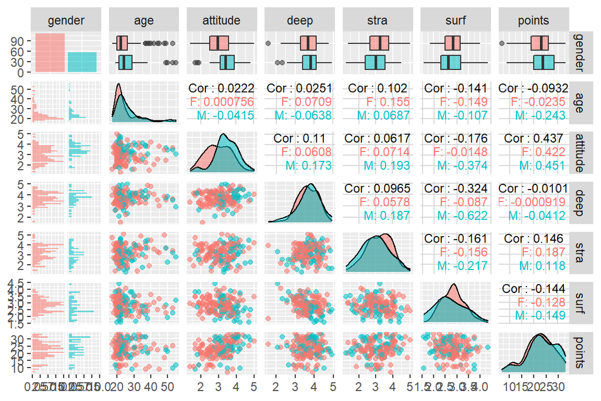

```r
# access libraries
library(ggplot2)
library(GGally)

# graphic overview

graphic_overview <- ggpairs(learning2014,
             mapping = aes(col = gender, alpha = 0.3),
             upper = list(continuous = wrap("cor", size = 3, alignPercent = 1)),
             lower = list(combo = wrap("facethist", bins = 30)))

graphic_overview
```

Scatter plots seem quite evenly spread - except for plots paired with age as most respondents are at the younger end.

**Side note**: If someone knows how to spread out the figure a little more in order to better see the values at the bottom, let me know!

## Regression model

To investigate what (combination of) the variables in the data could explain the level of success in the course exam, I am conducting a multivariate linear regression analysis. Regression analysis allow assessments of the relationship multiple independent variable sand a dependent variable. In multivariate regression models it is possible to have more than one independent variable which allows, e.g., controlling for possible confounding factors. The optimal set of independent variables is the smallest reliable uncorrelated set that explains enough of the variance in the dependent variable.

I first used attitude, strategic learning and deep learning as independent variables, but excluded both strategic and deep learning from the final model since they were not statistically significantly associated with the achieved exam points (as indicated by the p values above the 0.05 level and confidence intervals including zero). For the sake of the exercise, I tried plotting all the other variables as well but none of them reached statistical significance.

Hence, the final model is as follows:

```r
# regression model and summary
my_model <- lm(points ~ attitude, data = learning2014)
summary(my_model)
```

```
##
## Call:
## lm(formula = points ~ attitude, data = learning2014)
##
## Residuals:
##      Min       1Q   Median       3Q      Max
## -16.9763  -3.2119   0.4339   4.1534  10.6645
##
## Coefficients:
##             Estimate Std. Error t value Pr(>|t|)
## (Intercept)  11.6372     1.8303   6.358 1.95e-09 ***
## attitude      3.5255     0.5674   6.214 4.12e-09 ***
## ---
## Signif. codes:  0 '***' 0.001 '**' 0.01 '*' 0.05 '.' 0.1 ' ' 1
##
## Residual standard error: 5.32 on 164 degrees of freedom
## Multiple R-squared:  0.1906, Adjusted R-squared:  0.1856
## F-statistic: 38.61 on 1 and 164 DF,  p-value: 4.119e-09
```

```r
confint(my_model, level = 0.95)
```

```
##                2.5 %    97.5 %
## (Intercept) 8.023074 15.251233
## attitude    2.405135  4.645785
```

For a given predictor variable, the coefficient (Estimate) can be interpreted as the average effect on exam scores of a one unit increase in predictor, holding all other predictors fixed. So, a 1-point increase in attitude (on a scale from 1-5) will, on average, increase points achieved in the exam by 3.53.

## Diagnosic plots

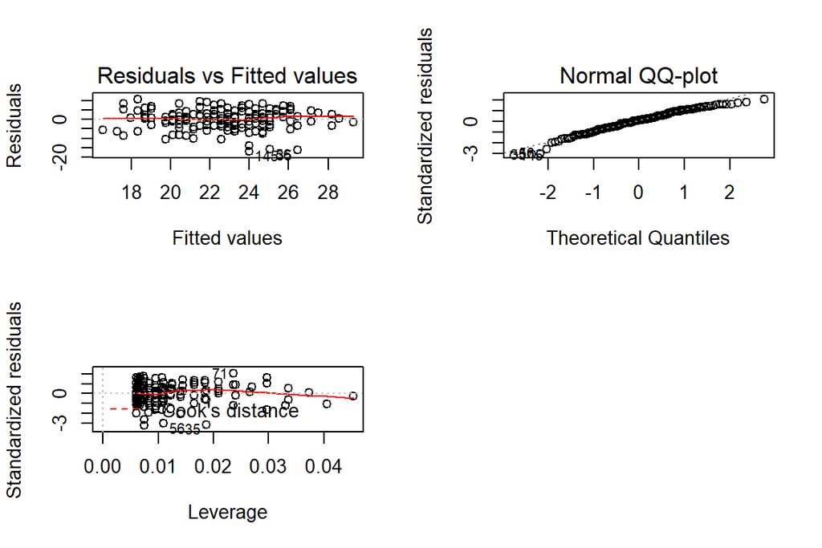

```r
# diagnostic plots
par(mfrow = c(2,2))
plot(my_model, which = c(1,2,5),
     caption = list("Residuals vs Fitted values", "Normal QQ-plot", "Residuals vs. Leverage"))
```

Multivariate regression assumes independence of the residuals, that is, normality, linearity, and homoscedasticity.

It is assumed that:

1. The errors are normally distributed
2. The errors are not correlated
3. The errors have constant variance
4. The size of a given error does not depend on the size of explanatory variables

The assumption of constant variance can be explored from the scatter plot where any pattern implies a violation of the assumption. Here, the pattern seems otherwise relatively random, but some clustering can be detected at the lower right-hand corner of the chart.

QQ- plot of the residuals provides a method to explore the assumption that the errors of the model are normally distributed. Here, the points fall nicely on the line in the middle, but some deviations can be detected at both ends, indicating a possible violation of this assumption.

For this model to better predict the exam scores, the more influential values and outliers should either be deleted or given a score that is not too far from the rest.

## Learning points

In this exercise I learned how to visualize data, conduct a simple regression analysis and create diagnostic plots. I have conducted regression analysis using SPSS before, so the method itself was not new. However, SPSS has only limited selection of diagnostic tools, and I had never seen nor analyzed a Leverage vs. Residuals scatter plot - so that was completely new to me!

In terms of using R, everything is always new! So this week I learned many useful commands to get started with basic analyses and built a good foundation to move on to more refined analyses.

# 3. Logistic regression analysis

The purpose of this analysis is to study the relationships between high/low alcohol consumption and some of the other variables in the data. The preceding data wrangling exercise is available [here.](https://github.com/palsola/IODS-project/blob/master/data/create_%20alc.R)

## Hypotheses

For this exercise, I chose 4 variables in the data that could have a relationship with alcohol consumption: quality of family relationships, number of school absences, current health status and sex. Hypotheses for each are as follows:

1. Quality of family relationships are negatively associated with alcohol consumption, i.e., the better the relationship, the less likely is high alcohol consumption.
2. Number of school absences are positively associated with alcohol consumption, i.e., the more absences, the more likely is high alcohol consumption.
3. Current health status is negatively associated with alcohol consumption, i.e., the better the health, the less likely is high alcohol consumption.
4. I am adding sex to the model mostly to control for its effects, but I also assume that male sex is positively associated with high alcohol consumption.

## Exploration of data

```r
students <- read.csv("C:/Users/minttu/R projects/IODS-project/data/students.csv")

# access the dplyr library
library(dplyr)
colnames(students)
```

```
##  [1] "school"     "sex"        "age"        "address"    "famsize"
##  [6] "Pstatus"    "Medu"       "Fedu"       "Mjob"       "Fjob"
## [11] "reason"     "nursery"    "internet"   "guardian"   "traveltime"
## [16] "studytime"  "failures"   "schoolsup"  "famsup"     "paid"
## [21] "activities" "higher"     "romantic"   "famrel"     "freetime"
## [26] "goout"      "Dalc"       "Walc"       "health"     "absences"
## [31] "G1"         "G2"         "G3"         "alc_use"    "high_use"
```

```r
keep_columns <- c("sex","famrel","health", "absences", "high_use")
alc <- select(students, one_of(keep_columns))
```

The whole dataset used for this exercise has 382 observations of 35 variables. For this exercise I will be using a subset with 382 observations of 5 variables.

Below is a summary table of all the variables as well as their bar plots. All variables except for sex seem to be skewed rather than normally distributed, which might affect the reliability of the logistic regression model.

```r
summary(alc)
```

```
##  sex         famrel          health         absences     high_use
##  F:198   Min.   :1.000   Min.   :1.000   Min.   : 0.0   Mode :logical
##  M:184   1st Qu.:4.000   1st Qu.:3.000   1st Qu.: 1.0   FALSE:268
##          Median :4.000   Median :4.000   Median : 3.0   TRUE :114
##          Mean   :3.937   Mean   :3.573   Mean   : 4.5
##          3rd Qu.:5.000   3rd Qu.:5.000   3rd Qu.: 6.0
##          Max.   :5.000   Max.   :5.000   Max.   :45.0
```

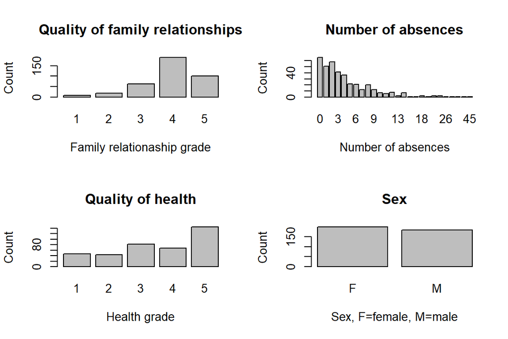

```r
par(mfrow=c(2,2))
# barplot of famrel
barplot(table(alc$famrel),
main="Quality of family relationships",
xlab="Family relationaship grade",
ylab="Count"
)

# barplot of absences
barplot(table(alc$absences),
main="Number of absences",
xlab="Number of absences",
ylab="Count"
)

# barplot of health
barplot(table(alc$health),
main="Quality of health",
xlab="Health grade",
ylab="Count"
)

# barplot of sex
barplot(table(alc$sex),
main="Sex",
xlab="Sex, F=female, M=male",
ylab="Count"
)
```

I used boxplots to explore the relationships between alcohol consumption family relations, health, and absences. I drew plots separately for females and males. In addition, I investigated the relationship between sex and alcohol consumption with cross tabulation.

Based on these, it seems that:

1. Quality of family relationships might be slightly negatively associated with alcohol consumption as hypothesized
2. Number of school absences might be positively associated with alcohol consumption as hypothesized.
3. Current health status is not associated with alcohol consumption contrary to initial hypothesis.
4. Male sex is positively associated with high alcohol consumption as hypothesized.

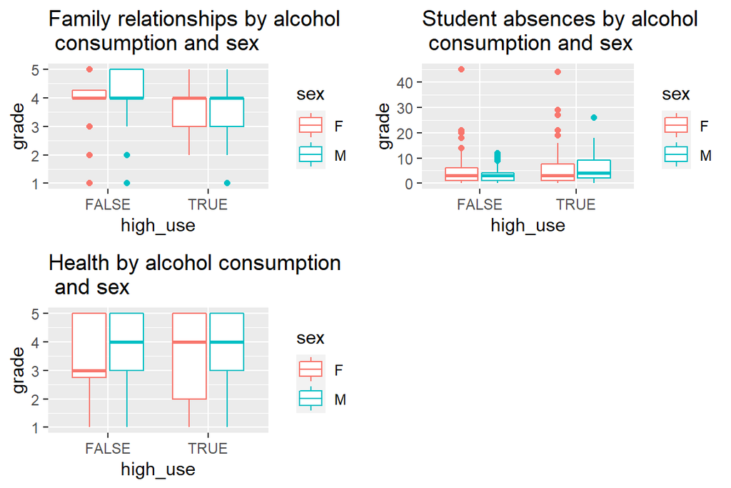

```r
# access libraries
library(ggplot2)

# a plot of high_use and family relations by sex
g1 <- ggplot(alc, aes(x = high_use, y = famrel, colour= sex)) + geom_boxplot() + ylab("grade") + ggtitle("Family relationships by alcohol \n consumption and sex")

# a plot of high_use and absences by sex
g2 <- ggplot(alc, aes(x = high_use, y = absences, colour= sex)) + geom_boxplot() + ylab("grade") + ggtitle("Student absences by alcohol \n consumption and sex")

# a plot of high_use and health by sex
g3 <- ggplot(alc, aes(x = high_use, y = health, colour= sex)) + geom_boxplot() + ylab("grade") + ggtitle("Health by alcohol consumption \n and sex")

library(gridExtra)
grid.arrange(g1, g2, g3, ncol=2)
```

```r
# a cross-tabulation of high_use and sex
table1 <- xtabs(~sex+high_use, data=alc)
ftable(table1)
```

```
##     high_use FALSE TRUE
## sex
## F              156   42
## M              112   72
```

```r
summary(table1)
```

```
## Call: xtabs(formula = ~sex + high_use, data = alc)
## Number of cases in table: 382
## Number of factors: 2
## Test for independence of all factors:
##  Chisq = 14.625, df = 1, p-value = 0.0001312
```

## Logistic regression

```r
# find the model with glm()
m <- glm(high_use ~ famrel + absences + health + sex, data = alc, family = "binomial")

# compute odds ratios (OR)
OR <- coef(m) %>% exp

# compute confidence intervals (CI)
CI <- confint(m) %>% exp

# print out the odds ratios with their confidence intervals
summary(m)
```

```
##
## Call:
## glm(formula = high_use ~ famrel + absences + health + sex, family = "binomial",
##     data = alc)
##
## Deviance Residuals:
##     Min       1Q   Median       3Q      Max
## -2.2557  -0.8609  -0.6151   1.0698   2.1157
##
## Coefficients:
##             Estimate Std. Error z value Pr(>|z|)
## (Intercept) -0.94806    0.58165  -1.630   0.1031
## famrel      -0.30625    0.12864  -2.381   0.0173 *
## absences     0.09375    0.02264   4.141 3.45e-05 ***
## health       0.08331    0.08779   0.949   0.3426
## sexM         1.00440    0.24498   4.100 4.13e-05 ***
## ---
## Signif. codes:  0 '***' 0.001 '**' 0.01 '*' 0.05 '.' 0.1 ' ' 1
##
## (Dispersion parameter for binomial family taken to be 1)
##
##     Null deviance: 465.68  on 381  degrees of freedom
## Residual deviance: 423.95  on 377  degrees of freedom
## AIC: 433.95
##
## Number of Fisher Scoring iterations: 4
```

```r
cbind(OR, CI)
```

```
##                    OR     2.5 %    97.5 %
## (Intercept) 0.3874923 0.1218232 1.2018295
## famrel      0.7362043 0.5708862 0.9470728
## absences    1.0982852 1.0527088 1.1506747
## health      1.0868775 0.9165274 1.2940911
## sexM        2.7302676 1.6999004 4.4499308
```

According to the regression model:

1. Family relationships are negatively associated with alcohol consumption (negative coefficient, p<.05, CI does not contain 1, and is <1)
2. Absences are positively associated with alcohol consumption (positive coefficient, p<0.001, CI does not contain 1, and is >1)
3. Health is not associated with alcohol consumption (p>.05, CI contains 1)
4. Male sex is positively associated with alcohol consumption (positive coefficient, p<.001, CI does not contain 1, and is >1)

Next, I will only use the variables that had a statistical relationship with high/low alcohol consumption, and explore the predictive power of this model.

```r
# model with sig IVs
m1 <- glm(high_use ~ famrel + absences + sex, data = alc, family = "binomial")

# predict() the probability of high_use
probabilities <- predict(m1, type = "response")

# add the predicted probabilities to 'alc'
alc <- mutate(alc, probability = probabilities)

# use the probabilities to make a prediction of high_use
alc <- mutate(alc, prediction = probability > 0.5)

# target variable versus the predictions
table(high_use = alc$high_use, prediction = alc$prediction)
```

```
##         prediction
## high_use FALSE TRUE
##    FALSE   256   12
##    TRUE     85   29
```

```r
table(high_use = alc$high_use, prediction = alc$prediction) %>% prop.table %>% addmargins
```

```
##         prediction
## high_use      FALSE       TRUE        Sum
##    FALSE 0.67015707 0.03141361 0.70157068
##    TRUE  0.22251309 0.07591623 0.29842932
##    Sum   0.89267016 0.10732984 1.00000000
```

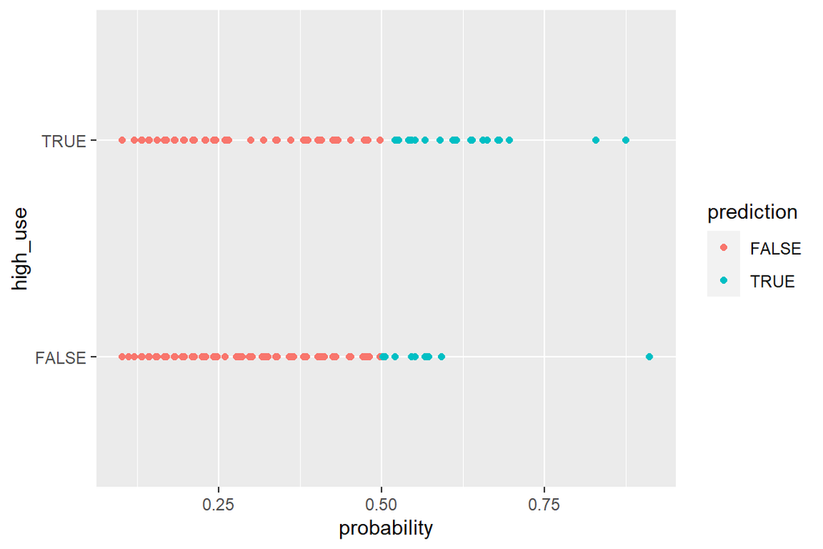

```r
# a plot of 'high_use' versus 'probability' in 'alc'
g <- ggplot(alc, aes(x = probability, y = high_use, col = prediction))
g + geom_point()
```

```r
# define a loss function (average prediction error)
loss_func <- function(class, prob) {
  n_wrong <- abs(class - prob) > 0.5
  mean(n_wrong)
}

# call loss_func to compute the average number of wrong predictions in the (training) data
loss <- loss_func(class = alc$high_use, prob = alc$probability)
```

According to the 2x2 cross tabulation of predictions versus the actual values, it seems like the model is not perfect in predicting alcohol use. Based on the cross tabulation, it is better in predicting true low use rather than true high use. The same is true when examining probabilities in cross tabulation and plot.

The average number of wrong predictions in the data is 0.2539267, which is not too bad.

## Cross validation

```r
# K-fold cross-validation
library(boot)
cv <- cv.glm(data = alc, cost = loss_func, glmfit = m1, K = 10)

# average number of wrong predictions in the cross validation
wrong_pred <- cv$delta[1]
```

```r
#Super-Bonus: Perform cross-validation to compare the performance of different logistic regression models (= different sets of predictors). Start with a very high number of predictors and explore the changes in the training and testing errors as you move to models with less predictors. Draw a graph displaying the trends of both training and testing errors by the number of predictors in the model. (0-4 points to compensate any loss of points from the above exercises)
```

[output not shown]